# 마크다운 연슴

이 자류는 마크다운 문법을 연습해보는 것이다.

## 제목에 대하여

제목은 ===와 —로 표시할 수 있다.

# 제목1

# 제목

## 제목 2

### 제목 3

#### 제목 4

## 단락(본문)

단락은 특별한 기호 없이 그대로 사용한다. 특별한 경우가 아니라면 들여쓰기를 하지 않는다.

단락과 단락 사이는 하나 이상의 빈 줄로 구분한다.

임의로 줄을 바꾸기 위해서는 두개 이상의 빈칸(space)를 쓴 다음 새로운 줄을 쓴다.

## 순서가 없는 목록

- 수박
- 참외
- 호박
- 오이

## 순서가 있는 목록

1. 수박
2. 참외
3. 호박
4. 오이이

1. Item 1
2. Item 2
3. Item 3

## 인용문단

> 다른 곳에서 인용했다는 표시를 하기 위해 > 기호를 쓴다.

## 컴퓨터 코드

블록 코드는 백틱 3개로 구분한다. 인라인 코드는 백틱 1개로 구분한다. 백틱은 보통 키보드에서 좌측 상단 TAB키 위에 있다.

```
This text is displayed verbatim / preformatted
```

we defined the `add` function to compute the sum of two numbers.

## 그림 삽입

alt text는 그림을 불러오지 못했을 때 대신 보여줄 텍스트를 의미한다.

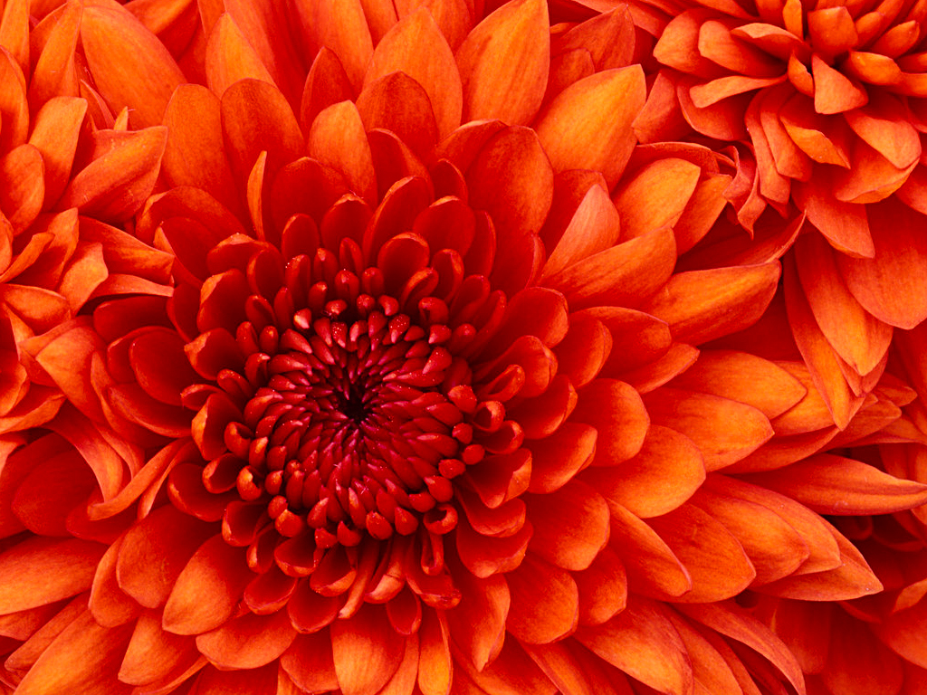

alt text

## 링크

http 주소를 직접 사용한다.

http://google.co.kr

단어등에 하이퍼 링크를 붙인다. []안에 단어를 넣고 주소는 ()안에 넣는다.

[구글](http://google.co.kr)